# Power cutoffs in the United States

Andrew Ba Tran

2/12/2017

# Are people dying from having their power cut off?

## An exploratory analysis

I noticed an article in the Austin-American Statesman with the headline: “Austin Energy warns against phone scammers threatening to cut power off.”

What would happen if people really were delinquent in payment and their power was eventually cut off? Imagine having no power at this moment in the winter. No lights, heat, hot water, or a way to cook.

I did some research— several states have laws that prevent people from living without heat during winter months. Other states make exceptions on cutting off power when the temperature goes below or above a certain threshold. Some states have both exemptions based on dates and temperatures. Others have neither. Here’s [the list](https://liheapch.acf.hhs.gov/Disconnect/disconnect.htm) which I’ve cleaned up and used below.

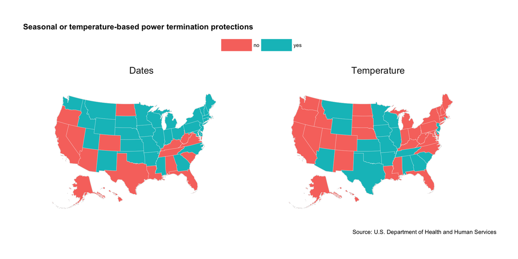

```r
library(albersusa)
library(sf)
library(sp)
library(rgeos)
library(maptools)
library(ggplot2)
library(ggalt)
library(ggthemes)
library(viridis)
library(scales)

library(tidyverse)

us <- usa_composite()
us_map <- fortify(us, region="name")
states_en <- read.csv("state_energy_cutoffs.csv", stringsAsFactors=F)


states_en_date <- states_en

states_en_date$based <- states_en_date$date.based
states_en_date$based_type <- "Dates"
states_en_temp <- states_en

states_en_temp$based <- states_en_date$temp.based
states_en_temp$based_type <- "Temperature"

states_en_total <- rbind(states_en_date, states_en_temp)


par(mar=c(0,0,1,0))

gg <- ggplot()
gg <- gg + geom_map(data=us_map, map=us_map,
                    aes(x=long, y=lat, map_id=id),
                    color="#2b2b2b", size=0.1, fill=NA)
gg <- gg + geom_map(data=states_en_total, map=us_map,
           aes(fill=based, map_id=state),
           color="white", size=0.1)
gg <- gg + coord_proj(us_laea_proj)
#gg <- gg + theme_map(base_family="Arial Narrow")
gg <- gg + theme_map()

gg <- gg + scale_fill_discrete(name=NULL)
gg <- gg +  theme(legend.position="top", legend.justification="center",
        legend.key.width=unit(3, "lines"))
gg <- gg +  facet_wrap(~based_type)
gg <- gg + labs(x=NULL, y=NULL,
                title="Seasonal or temperature-based power termination protections",
                caption="Source: U.S. Department of Health and Human Services")
gg <- gg + theme(panel.grid.major.y=element_blank())
gg <- gg + theme(panel.grid.minor=element_blank())
gg <- gg + theme(axis.line.y=element_line(color="#2b2b2b", size=0.15))
gg <- gg + theme(axis.text.y=element_text(margin=margin(r=-5, l=0)))
gg <- gg + theme(plot.margin=unit(rep(30, 4), "pt"))
gg <- gg + theme(plot.title=element_text(face="bold"))
gg <- gg + theme(plot.subtitle=element_text(margin=margin(b=10)))
gg <- gg + theme(plot.caption=element_text(size=8, margin=margin(t=10)))
gg <- gg + theme(strip.background = element_blank(),strip.text = element_text(size=13))

gg
```

Researchers say more people die [from cold weather](https://www.washingtonpost.com/news/capital-weather-gang/wp/2014/08/04/cold-kills-more-than-heat-cdc-says-but-researchers-caution-it-depends/?utm_term=.7d9e6a78f707) than hot. Are rates of death higher in states that provide no power safety net?

```r
#deaths <- read.table("hypo_hyper_1999_2015.txt", sep="\t", header=T)
#deaths <- read.table("hypo_hyper_2005_2015.txt", sep="\t", header=T)
deaths <- read.table("multiple_causes2015.txt", sep="\t", header=T)

cold_deaths <- subset(deaths, Multiple.Cause.of.death.Code=="X31")
cold_deaths$rate <- round(cold_deaths$Deaths/cold_deaths$Population*1000000,1)
names(cold_deaths)[names(cold_deaths) == 'State'] <- 'state'

cold_deaths <- cold_deaths %>%
  group_by(state) %>%
  summarize(rate=mean(rate))

heat_deaths <- subset(deaths, Multiple.Cause.of.death.Code=="X30")
heat_deaths$rate <- round(heat_deaths$Deaths/heat_deaths$Population*1000000,1)
names(heat_deaths)[names(heat_deaths) == 'State'] <- 'state'
heat_deaths <- heat_deaths %>%
  group_by(state) %>%
  summarize(rate=mean(rate))


states_en_cold <- left_join(states_en_total, cold_deaths)
states_en_heat <- left_join(states_en_total, heat_deaths)
states_en_cold$death <- "hypothermia"
states_en_heat$death <- "hyperthermia"

states_en_death <- rbind(states_en_cold, states_en_heat)


states_en_death$date.temp <- ""
states_en_death$date.temp <- ifelse(states_en_death$date.based=="no" & states_en_death$temp.based=="no", "no",  states_en_death$date.temp)
states_en_death$date.temp <- ifelse(states_en_death$date.based=="yes" & states_en_death$temp.based=="no", "mixed",  states_en_death$date.temp)
states_en_death$date.temp <- ifelse(states_en_death$date.based=="no" & states_en_death$temp.based=="yes", "mixed",  states_en_death$date.temp)
states_en_death$date.temp <- ifelse(states_en_death$date.based=="yes" & states_en_death$temp.based=="yes", "yes",  states_en_death$date.temp)


power_no <- subset(states_en_death, date.temp=="no" & death=="hypothermia")
power_yes <- subset(states_en_death, date.temp=="yes" & death=="hypothermia")
power_mixed <- subset(states_en_death, date.temp=="mixed" & death=="hypothermia")
```

A deeper analysis would have to adjust for the likelihood of higher rates in colder states.

The average rate for hypothermia deaths is 8.7 in states without temperature or dates-based power protections. In states with one of those protections, the rate is 6.1; states with both protections have a death rate of 5.5.

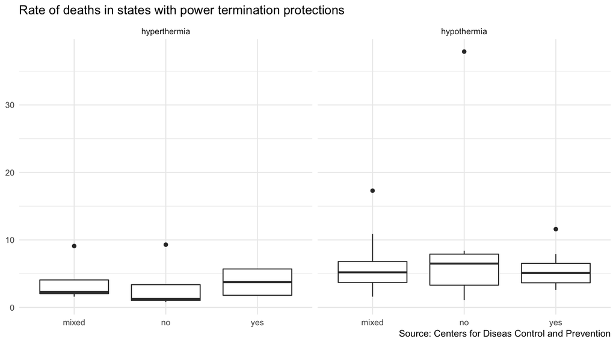

```r
boxp <- ggplot(states_en_death, aes(date.temp, rate))
boxp <- boxp + geom_boxplot()
boxp <- boxp + facet_wrap(~death)
boxp <- boxp + labs(x=NULL, y=NULL,
                title="Rate of deaths in states with power termination protections",
                caption="Source: Centers for Diseas Control and Prevention")
boxp <- boxp + theme(panel.grid.major.y=element_blank())
boxp <- boxp + theme(panel.grid.minor=element_blank())
boxp <- boxp + theme(axis.line.y=element_line(color="#2b2b2b", size=0.15))
boxp <- boxp + theme(axis.text.y=element_text(margin=margin(r=-5, l=0)))
boxp <- boxp + theme(plot.margin=unit(rep(30, 4), "pt"))
boxp <- boxp + theme(plot.title=element_text(face="bold"))
boxp <- boxp + theme(plot.subtitle=element_text(margin=margin(b=10)))
boxp <- boxp + theme(plot.caption=element_text(size=8, margin=margin(t=10)))
#boxp <- boxp + theme(strip.background = element_blank(),strip.text = element_text(size=15))
boxp <- boxp + theme_minimal()

boxp
```

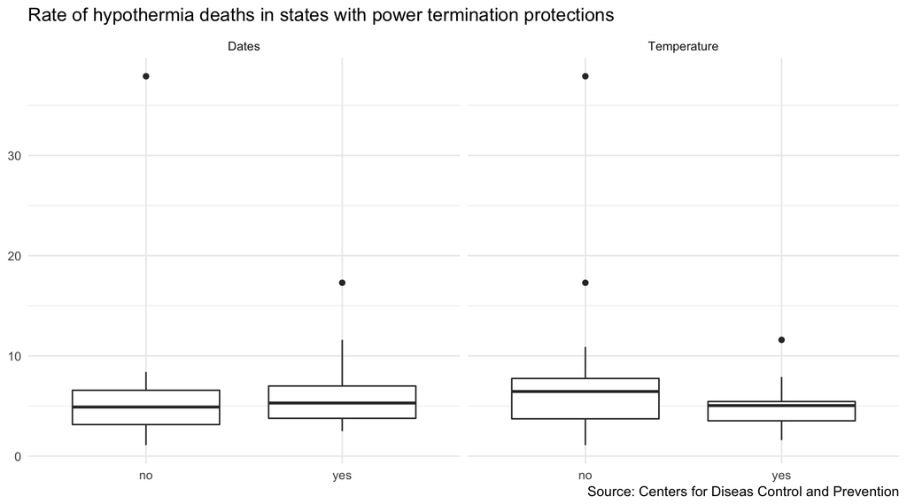

```r
boxp <- ggplot(states_en_cold, aes(based, rate))
boxp <- boxp + geom_boxplot()
boxp <- boxp + facet_wrap(~based_type)
boxp <- boxp + labs(x=NULL, y=NULL,
                    title="Rate of hypothermia deaths in states with power termination protections",
                    caption="Source: Centers for Diseas Control and Prevention")
boxp <- boxp + theme(panel.grid.major.y=element_blank())
boxp <- boxp + theme(panel.grid.minor=element_blank())
boxp <- boxp + theme(axis.line.y=element_line(color="#2b2b2b", size=0.15))
boxp <- boxp + theme(axis.text.y=element_text(margin=margin(r=-5, l=0)))
boxp <- boxp + theme(plot.margin=unit(rep(30, 4), "pt"))
boxp <- boxp + theme(plot.title=element_text(face="bold"))
boxp <- boxp + theme(plot.subtitle=element_text(margin=margin(b=10)))
boxp <- boxp + theme(plot.caption=element_text(size=8, margin=margin(t=10)))
#boxp <- boxp + theme(strip.background = element_blank(),strip.text = element_text(size=15))
boxp <- boxp + theme_minimal()

boxp
```